# User Guide: 1 Debugging ggplots

‘gginnards’ 0.0.1

Pedro J. Aphalo

2018-07-05

## Preliminaries

```r
library(ggplot2)
library(gginnards)
library(tibble)
```

We generate some artificial data.

```r
set.seed(4321)
# generate artificial data
x <- 1:100
y <- (x + x^2 + x^3) + rnorm(length(x), mean = 0, sd = mean(x^3) / 4)
my.data <- data.frame(x,
                      y,
                      group = c("A", "B"),
                      y2 = y * c(0.5, 2),
                      block = c("a", "a", "b", "b"))
```

We change the default theme to an uncluttered one.

```r
old_theme <- theme_set(theme_bw())
```

## Introduction

Package ‘ggplot2’ defines its own class system, and function `ggplot()` can be considered as a constructor.

```r
class(ggplot())
```

```
## [1] "gg"     "ggplot"
```

If we pass no arguments an empty plot is constructed.

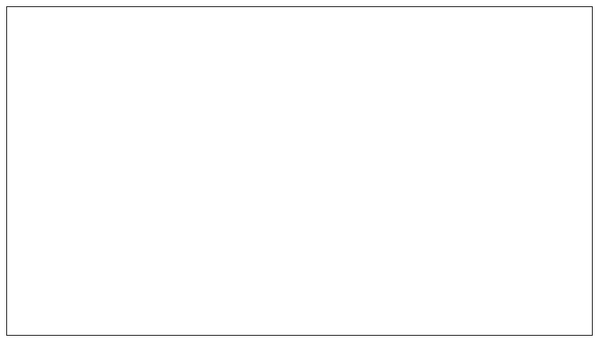

```r
ggplot()
```

The structure of bjects of classes `"gg"` `"ggplot"` can be explored with R’s method `str()` as any other structured R objects. These allows us to see the different *slots* of these special type of lists.

```r
str(ggplot())
```

```
## List of 9
##  $ data       : list()
##   ..- attr(*, "class")= chr "waiver"
##  $ layers     : list()
##  $ scales     :Classes 'ScalesList', 'ggproto', 'gg' <ggproto object: Class ScalesList, gg>
##     add: function
##     clone: function
##     find: function
##     get_scales: function
##     has_scale: function
##     input: function
##     n: function
##     non_position_scales: function
##     scales: NULL
##     super:  <ggproto object: Class ScalesList, gg>
##  $ mapping    : Named list()
##   ..- attr(*, "class")= chr "uneval"
##  $ theme      : list()
##  $ coordinates:Classes 'CoordCartesian', 'Coord', 'ggproto', 'gg' <ggproto object: Class CoordCartesian, Coord, gg>
##     aspect: function
##     clip: on
##     default: TRUE
##     distance: function
##     expand: TRUE
##     is_free: function
##     is_linear: function
##     labels: function
##     limits: list
##     modify_scales: function
##     range: function
##     render_axis_h: function
##     render_axis_v: function
##     render_bg: function
##     render_fg: function
##     setup_data: function
##     setup_layout: function
##     setup_panel_params: function
##     setup_params: function
##     transform: function
##     super:  <ggproto object: Class CoordCartesian, Coord, gg>
##  $ facet      :Classes 'FacetNull', 'Facet', 'ggproto', 'gg' <ggproto object: Class FacetNull, Facet, gg>
##     compute_layout: function
##     draw_back: function
##     draw_front: function
##     draw_labels: function
##     draw_panels: function
##     finish_data: function
##     init_scales: function
##     map_data: function
##     params: list
##     setup_data: function
##     setup_params: function
##     shrink: TRUE
##     train_scales: function
##     vars: function
##     super:  <ggproto object: Class FacetNull, Facet, gg>
##  $ plot_env   :<environment: R_GlobalEnv>
##  $ labels     : Named list()
##  - attr(*, "class")= chr [1:2] "gg" "ggplot"
```

If we pass an argument to parameter `data` the data is copied into the list slot with name `data`. As we also map the data to aesthetics, this mapping is stored in slot `maaping`.

```r
str(ggplot(data = my.data, aes(x, y, colour = group)))
```

```
## List of 9
##  $ data       :'data.frame': 100 obs. of  5 variables:
##   ..$ x    : int [1:100] 1 2 3 4 5 6 7 8 9 10 ...
##   ..$ y    : num [1:100] -27205 -14243 45791 53731 -8029 ...
##   ..$ group: Factor w/ 2 levels "A","B": 1 2 1 2 1 2 1 2 1 2 ...
##   ..$ y2   : num [1:100] -13603 -28485 22895 107463 -4014 ...
##   ..$ block: Factor w/ 2 levels "a","b": 1 1 2 2 1 1 2 2 1 1 ...
##  $ layers     : list()
##  $ scales     :Classes 'ScalesList', 'ggproto', 'gg' <ggproto object: Class ScalesList, gg>
##     add: function
##     clone: function
##     find: function
##     get_scales: function
##     has_scale: function
##     input: function
##     n: function
##     non_position_scales: function
##     scales: NULL
##     super:  <ggproto object: Class ScalesList, gg>
##  $ mapping    :List of 3
##   ..$ x     : language ~x
##   .. ..- attr(*, ".Environment")=<environment: R_GlobalEnv>
##   ..$ y     : language ~y
##   .. ..- attr(*, ".Environment")=<environment: R_GlobalEnv>
##   ..$ colour: language ~group
##   .. ..- attr(*, ".Environment")=<environment: R_GlobalEnv>
##   ..- attr(*, "class")= chr "uneval"
##  $ theme      : list()
##  $ coordinates:Classes 'CoordCartesian', 'Coord', 'ggproto', 'gg' <ggproto object: Class CoordCartesian, Coord, gg>
##     aspect: function
##     clip: on
##     default: TRUE
##     distance: function
##     expand: TRUE
##     is_free: function
##     is_linear: function
##     labels: function
##     limits: list
##     modify_scales: function
##     range: function
```

[output cut: 17 more lines]

```
##     init_scales: function
##     map_data: function
##     params: list
##     setup_data: function
##     setup_params: function
##     shrink: TRUE
##     train_scales: function
##     vars: function
##     super:  <ggproto object: Class FacetNull, Facet, gg>
##  $ plot_env   :<environment: R_GlobalEnv>
##  $ labels     :List of 3
##   ..$ x     : chr "x"
##   ..$ y     : chr "y"
##   ..$ colour: chr "group"
##  - attr(*, "class")= chr [1:2] "gg" "ggplot"
```

A `summary()` method that produces a more compact output is available in recent versions of ‘ggplot2’. However, it does not reveal the internal structure of the objects.

```r
summary(ggplot(data = my.data, aes(x, y, colour = group)) +
          geom_point())
```

```
## data: x, y, group, y2, block [100x5]
## mapping:  x = ~x, y = ~y, colour = ~group
## faceting: <ggproto object: Class FacetNull, Facet, gg>
##     compute_layout: function
##     draw_back: function
##     draw_front: function
##     draw_labels: function
##     draw_panels: function
##     finish_data: function
##     init_scales: function
##     map_data: function
##     params: list
##     setup_data: function
##     setup_params: function
##     shrink: TRUE
##     train_scales: function
##     vars: function
##     super:  <ggproto object: Class FacetNull, Facet, gg>
## -----------------------------------
## geom_point: na.rm = FALSE
## stat_identity: na.rm = FALSE
## position_identity
```

How does mapping work? *Geometries* (geoms) and *statistics* (stats) do not “see” the original variable names, instead the `data` passed to them is named according to the *aesthetics* user variables are mapped to. Geoms and stats work in tandem, with geoms doing the actual plotting and stats summarizing or transforming the data. It can be instructive to be able to see what data is received as input by a geom or stat, and what data is returned by a stat.

Both geoms and stats can have either panel- or group functions. Panel functions receive as input the subset of the data that corresponds to a whole panel, mapped to the aesthetics and with factors indicating the grouping (set by the user by mapping to a discrete scale). Group functions receive as input the subset of data correspoding to a single group based on the mapping.

The motivation for writing the “debug” stats and geoms included in package ‘gginnards’ is that at the moment it is in many cases not possible to set breakpoints inside the code of stats and geoms, because frequently nameless panel and group functions are stored in list-like objects used to store the definitions of geoms and stats.

This can make it tedious to analyze how these functions work, as one may need to add `print` statements to their source code to see the data. I wrote the “debug” stats and geoms as tools to help in the development of my packages ‘ggpmisc’ and ‘ggspectra’, and as a way of learning myself how data are passed around within the different components of a `ggplot` object when it is printed.

The stats described in this vignette are very simple and print a summary of their `data` input by default to the console, but the function used to dispaly the data can be passed as an argument, adding flexibility. The debug stats, in addition return a data frame containing labels suitable for plotting with geom “text” or geom “label”. However, as default geom “null” is used, they do not alter the plot itself unless a different geom is explicitly passed as argument.

Because of the way ‘ggplot2’ works, the values are listed to the console at the time when the `ggplot` object is printed. As shown here, no other geom or stat is required, however in the remaining examples we add `geom_point()` to make the data also visible in the plot.

```
## [1] "Input 'data' to 'compute_group()':"
## # A tibble: 100 x 4
##        x        y PANEL group
##  * <dbl>    <dbl> <fct> <int>
##  1     1  -27205. 1        -1
##  2     2  -14243. 1        -1
##  3     3   45791. 1        -1
##  4     4   53731. 1        -1
##  5     5   -8029. 1        -1
##  6     6  102864. 1        -1
##  7     7  -18547. 1        -1
##  8     8   13081. 1        -1
##  9     9   79924. 1        -1
## 10    10  -44711. 1        -1
## # ... with 90 more rows
```

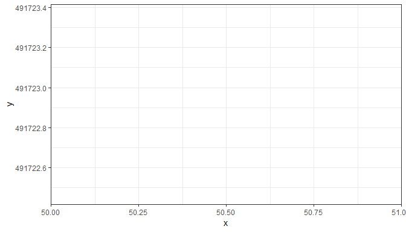

```r
ggplot(my.data, aes(x, y)) + stat_debug_group()
```

In the absence of facets or groups we get just get the summary from one data frame.

```r
ggplot(my.data, aes(x, y)) + geom_point() + stat_debug_group()
```

```
## [1] "Input 'data' to 'compute_group()':"
## # A tibble: 100 x 4
##        x        y PANEL group
##  * <dbl>    <dbl> <fct> <int>
##  1     1  -27205. 1        -1
##  2     2  -14243. 1        -1
##  3     3   45791. 1        -1
##  4     4   53731. 1        -1
##  5     5   -8029. 1        -1
##  6     6  102864. 1        -1
##  7     7  -18547. 1        -1
##  8     8   13081. 1        -1
##  9     9   79924. 1        -1
## 10    10  -44711. 1        -1
## # ... with 90 more rows
```

```r
ggplot(my.data, aes(x, y)) + geom_point() + stat_debug_panel()
```

```
## [1] "Input 'data' to 'compute_panel()':"
## # A tibble: 100 x 4
##        x        y PANEL group
##    <dbl>    <dbl> <fct> <int>
##  1     1  -27205. 1        -1
##  2     2  -14243. 1        -1
##  3     3   45791. 1        -1
##  4     4   53731. 1        -1
##  5     5   -8029. 1        -1
##  6     6  102864. 1        -1
##  7     7  -18547. 1        -1
##  8     8   13081. 1        -1
##  9     9   79924. 1        -1
## 10    10  -44711. 1        -1
## # ... with 90 more rows
```

In the case of grouping then one data frame is summarized for each group in the ggplot object.

```r
ggplot(my.data, aes(x, y, colour = group)) + geom_point() +
  stat_debug_group()
```

```
## [1] "Input 'data' to 'compute_group()':"
## # A tibble: 50 x 5
##        x       y colour PANEL group
##  * <dbl>   <dbl> <fct>  <fct> <int>
##  1     1 -27205. A      1         1
##  2     3  45791. A      1         1
##  3     5  -8029. A      1         1
##  4     7 -18547. A      1         1
##  5     9  79924. A      1         1
##  6    11  -2824. A      1         1
##  7    13 -78017. A      1         1
##  8    15 -74281. A      1         1
##  9    17   9904. A      1         1
## 10    19 -94023. A      1         1
## # ... with 40 more rows
## [1] "Input 'data' to 'compute_group()':"
## # A tibble: 50 x 5
##        x        y colour PANEL group
##  * <dbl>    <dbl> <fct>  <fct> <int>
##  1     2  -14243. B      1         2
##  2     4   53731. B      1         2
##  3     6  102864. B      1         2
##  4     8   13081. B      1         2
##  5    10  -44711. B      1         2
##  6    12   23840. B      1         2
##  7    14   75602. B      1         2
##  8    16  104677. B      1         2
##  9    18  -68747. B      1         2
## 10    20  -39230. B      1         2
## # ... with 40 more rows
```

Without facets, we still have only one panel.

```r
ggplot(my.data, aes(x, y, colour = group)) + geom_point() +
  stat_debug_panel()
```

```
## [1] "Input 'data' to 'compute_panel()':"
## # A tibble: 100 x 5
##        x        y colour PANEL group
##    <dbl>    <dbl> <fct>  <fct> <int>
##  1     1  -27205. A      1         1
##  2     2  -14243. B      1         2
##  3     3   45791. A      1         1
##  4     4   53731. B      1         2
##  5     5   -8029. A      1         1
##  6     6  102864. B      1         2
##  7     7  -18547. A      1         1
##  8     8   13081. B      1         2
##  9     9   79924. A      1         1
## 10    10  -44711. B      1         2
## # ... with 90 more rows
```

The data are similar, except for the column named after the aesthetic, for the aesthetics used for grouping.

```
## [1] "Input 'data' to 'compute_group()':"
## # A tibble: 50 x 5
##        x       y shape PANEL group
##  * <dbl>   <dbl> <fct> <fct> <int>
##  1     1 -27205. A     1         1
##  2     3  45791. A     1         1
##  3     5  -8029. A     1         1
##  4     7 -18547. A     1         1
##  5     9  79924. A     1         1
##  6    11  -2824. A     1         1
##  7    13 -78017. A     1         1
##  8    15 -74281. A     1         1
##  9    17   9904. A     1         1
## 10    19 -94023. A     1         1
## # ... with 40 more rows
## [1] "Input 'data' to 'compute_group()':"
## # A tibble: 50 x 5
##        x        y shape PANEL group
##  * <dbl>    <dbl> <fct> <fct> <int>
##  1     2  -14243. B     1         2
##  2     4   53731. B     1         2
##  3     6  102864. B     1         2
##  4     8   13081. B     1         2
##  5    10  -44711. B     1         2
##  6    12   23840. B     1         2
##  7    14   75602. B     1         2
##  8    16  104677. B     1         2
##  9    18  -68747. B     1         2
## 10    20  -39230. B     1         2
## # ... with 40 more rows
```

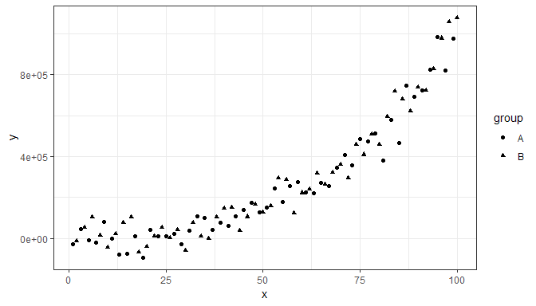

```r
ggplot(my.data, aes(x, y, shape = group)) + geom_point() +
  stat_debug_group()
```

If we use as *geom* `"label"` or `"text"` a *debug* summary is added to the plot itself, we can use other arguments valid for the *geom* used, in this case `vjust`.

```
## [1] "Input 'data' to 'compute_group()':"
## # A tibble: 50 x 5
##        x       y shape PANEL group
##  * <dbl>   <dbl> <fct> <fct> <int>
##  1     1 -27205. A     1         1
##  2     3  45791. A     1         1
##  3     5  -8029. A     1         1
##  4     7 -18547. A     1         1
##  5     9  79924. A     1         1
##  6    11  -2824. A     1         1
##  7    13 -78017. A     1         1
##  8    15 -74281. A     1         1
##  9    17   9904. A     1         1
## 10    19 -94023. A     1         1
## # ... with 40 more rows
## [1] "Input 'data' to 'compute_group()':"
## # A tibble: 50 x 5
##        x        y shape PANEL group
##  * <dbl>    <dbl> <fct> <fct> <int>
##  1     2  -14243. B     1         2
##  2     4   53731. B     1         2
##  3     6  102864. B     1         2
##  4     8   13081. B     1         2
##  5    10  -44711. B     1         2
##  6    12   23840. B     1         2
##  7    14   75602. B     1         2
##  8    16  104677. B     1         2
##  9    18  -68747. B     1         2
## 10    20  -39230. B     1         2
## # ... with 40 more rows
```

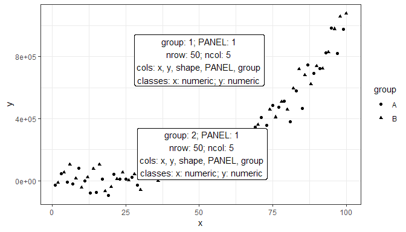

```r
ggplot(my.data, aes(x, y, shape = group)) + geom_point() +
  stat_debug_group(geom = "label", vjust = c(-0.5,1.5))
```

The summary function can be a user defined one, which allows lots of flexibility.

```r
ggplot(my.data, aes(x, y)) + geom_point() +
  stat_debug_group(summary.fun = summary)
```

```
## [1] "Input 'data' to 'compute_group()':"
##        x                y           PANEL       group
##  Min.   :  1.00   Min.   : -94023   1:100   Min.   :-1
##  1st Qu.: 25.75   1st Qu.:  40345           1st Qu.:-1
##  Median : 50.50   Median : 154036           Median :-1
##  Mean   : 50.50   Mean   : 266433           Mean   :-1
##  3rd Qu.: 75.25   3rd Qu.: 422069           3rd Qu.:-1
##  Max.   :100.00   Max.   :1077469           Max.   :-1
```

```r
ggplot(my.data, aes(x, y)) + geom_point() +
  stat_debug_group(summary.fun = head)
```

```
## [1] "Input 'data' to 'compute_group()':"
##   x          y PANEL group
## 1 1 -27205.450     1    -1
## 2 2 -14242.651     1    -1
## 3 3  45790.918     1    -1
## 4 4  53731.420     1    -1
## 5 5  -8028.578     1    -1
## 6 6 102863.943     1    -1
```

```r
ggplot(my.data, aes(x, y)) + geom_point() +
  stat_debug_group(summary.fun = nrow)
```

```
## [1] "Input 'data' to 'compute_group()':"
## [1] 100
```

The default.

```r
ggplot(my.data, aes(x, y)) + geom_point() +
  stat_debug_group(summary.fun = as_tibble)
```

```
## [1] "Input 'data' to 'compute_group()':"
## # A tibble: 100 x 4
##        x        y PANEL group
##  * <dbl>    <dbl> <fct> <int>
##  1     1  -27205. 1        -1
##  2     2  -14243. 1        -1
##  3     3   45791. 1        -1
##  4     4   53731. 1        -1
##  5     5   -8029. 1        -1
##  6     6  102864. 1        -1
##  7     7  -18547. 1        -1
##  8     8   13081. 1        -1
##  9     9   79924. 1        -1
## 10    10  -44711. 1        -1
## # ... with 90 more rows
```

```r
ggplot(my.data, aes(x, y)) + geom_point() +
  stat_debug_group(summary.fun = head, summary.fun.args = list(n = 3))
```

```
## [1] "Input 'data' to 'compute_group()':"
##   x         y PANEL group
## 1 1 -27205.45     1    -1
## 2 2 -14242.65     1    -1
## 3 3  45790.92     1    -1
```

This next chunk showing how to print the whole data frame is not run as its output is more than 100 lines long as the data set contains 100 observations.

```r
ggplot(my.data, aes(x, y)) + geom_point() +
  stat_debug_group(summary.fun = function(x) {x})
```

With grouping, for each *group* the `compute_group()` function is called with a subset of the data.

```r
ggplot(my.data, aes(x, y, colour = group)) + geom_point() +
  stat_debug_group(summary.fun = head, summary.fun.args = list(n = 3))
```

```
## [1] "Input 'data' to 'compute_group()':"
##   x          y colour PANEL group
## 1 1 -27205.450      A     1     1
## 3 3  45790.918      A     1     1
## 5 5  -8028.578      A     1     1
## [1] "Input 'data' to 'compute_group()':"
##   x         y colour PANEL group
## 2 2 -14242.65      B     1     2
## 4 4  53731.42      B     1     2
## 6 6 102863.94      B     1     2
```

In this example with grouping and facets, within each *panel* the `compute_group()` function is called for each group, in total four times.

```
## [1] "Input 'data' to 'compute_group()':"
## [1] 25
## [1] "Input 'data' to 'compute_group()':"
## [1] 25
## [1] "Input 'data' to 'compute_group()':"
## [1] 25
## [1] "Input 'data' to 'compute_group()':"
## [1] 25
```

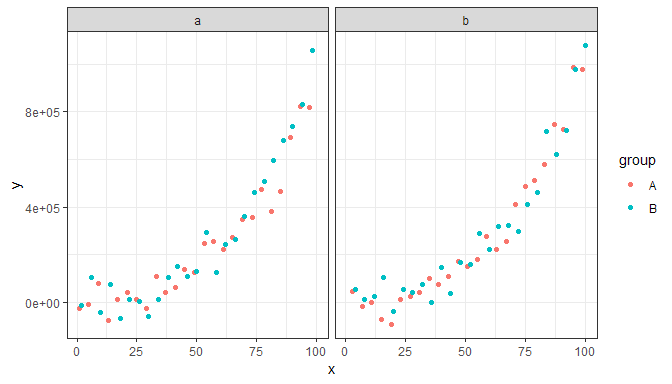

```r
ggplot(my.data, aes(x, y, colour = group)) + geom_point() +
  stat_debug_group(summary.fun = nrow) +
  facet_wrap(~block)
```

With facets, for each *panel* the `compute_panel()` function is called with a subset of the data that is not split by groups. For our example, it is called twice.

```
## [1] "Input 'data' to 'compute_panel()':"
## [1] 50
## [1] "Input 'data' to 'compute_panel()':"
## [1] 50
```

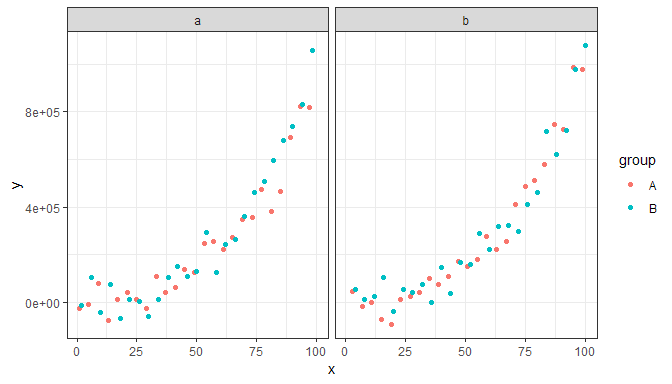

```r
ggplot(my.data, aes(x, y, colour = group)) + geom_point() +
  stat_debug_panel(summary.fun = nrow) +
  facet_wrap(~block)
```

Finally we show how `geom_debug()` can be used. First to print to the console the data as passed to geoms.

```r
ggplot(my.data, aes(x, y, colour = group)) + geom_point() +
  geom_debug(summary.fun = head)
```

```
##    colour x          y PANEL group
## 1 #F8766D 1 -27205.450     1     1
## 2 #00BFC4 2 -14242.651     1     2
## 3 #F8766D 3  45790.918     1     1
## 4 #00BFC4 4  53731.420     1     2
## 5 #F8766D 5  -8028.578     1     1
## 6 #00BFC4 6 102863.943     1     2
```

We may even save the data input of the geom to a variable in the global environment, but this takes place at the time the ggplot object is printed.

```r
pipe_assign <- function(value, name, pos = .GlobalEnv, ...) {
  assign(x = name, value = value, inherits = FALSE, pos = pos, ...)
}

ggplot(my.data, aes(x, y, colour = group)) +
  geom_point() +
  geom_debug(summary.fun = pipe_assign,
             summary.fun.args = list(name = "debug_data"),
             print.fun = NULL)

debug_data
```

```
##      colour   x             y PANEL group
## 1   #F8766D   1  -27205.45039     1     1
## 2   #00BFC4   2  -14242.65108     1     2
## 3   #F8766D   3   45790.91787     1     1
## 4   #00BFC4   4   53731.42037     1     2
## 5   #F8766D   5   -8028.57848     1     1
## 6   #00BFC4   6  102863.94292     1     2
## 7   #F8766D   7  -18547.28227     1     1
## 8   #00BFC4   8   13080.52133     1     2
## 9   #F8766D   9   79924.32504     1     1
## 10  #00BFC4  10  -44711.49916     1     2
## 11  #F8766D  11   -2823.73559     1     1
## 12  #00BFC4  12   23839.55471     1     2
## 13  #F8766D  13  -78016.69001     1     1
## 14  #00BFC4  14   75601.95706     1     2
```

[output cut: 86 more lines]

```r
ggplot(my.data, aes(x, y, colour = group)) + geom_point() +
  geom_debug(summary.fun = NULL)
```

```
##      colour   x             y PANEL group
## 1   #F8766D   1  -27205.45039     1     1
## 2   #00BFC4   2  -14242.65108     1     2
## 3   #F8766D   3   45790.91787     1     1
## 4   #00BFC4   4   53731.42037     1     2
## 5   #F8766D   5   -8028.57848     1     1
## 6   #00BFC4   6  102863.94292     1     2
## 7   #F8766D   7  -18547.28227     1     1
## 8   #00BFC4   8   13080.52133     1     2
## 9   #F8766D   9   79924.32504     1     1
## 10  #00BFC4  10  -44711.49916     1     2
## 11  #F8766D  11   -2823.73559     1     1
## 12  #00BFC4  12   23839.55471     1     2
## 13  #F8766D  13  -78016.69001     1     1
## 14  #00BFC4  14   75601.95706     1     2
```

[output cut: 86 more lines]

And also to print to the console the data returned by a stat.

```
## # A tibble: 160 x 8
##    colour      x        y     ymin     ymax     se PANEL group
##    <chr>   <dbl>    <dbl>    <dbl>    <dbl>  <dbl> <fct> <int>
##  1 #F8766D  1    -188136. -254711. -121562. 33111. 1         1
##  2 #F8766D  2.24 -176933. -242260. -111606. 32491. 1         1
##  3 #F8766D  3.48 -165730. -229819. -101641. 31875. 1         1
##  4 #F8766D  4.72 -154527. -217387.  -91668. 31263. 1         1
##  5 #F8766D  5.96 -143324. -204964.  -81684. 30657. 1         1
##  6 #F8766D  7.20 -132121. -192552.  -71691. 30055. 1         1
##  7 #F8766D  8.44 -120918. -180150.  -61686. 29459. 1         1
##  8 #F8766D  9.68 -109715. -167760.  -51670. 28869. 1         1
##  9 #F8766D 10.9   -98512. -155383.  -41642. 28285. 1         1
## 10 #F8766D 12.2   -87309. -143019.  -31600. 27707. 1         1
## # ... with 150 more rows
```

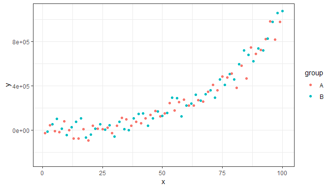

```r
ggplot(my.data, aes(x, y, colour = group)) + geom_point() +
  stat_smooth(method = "lm", geom = "debug")
```

The ‘gginnards’ package also defines a `"null"` geom, which is used as default by the *debug* *stats* described above. Currently this geom is similar to the recently added `ggplot2::geom_blank()`.

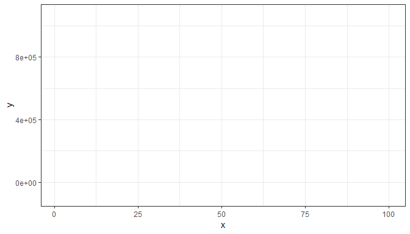

```r
ggplot(my.data, aes(x, y, colour = group)) + geom_null()
```